# Analyse survey responses

Ana Martinovici

2023-11-07 12:27:32

```r
library("tidyverse")
library("Cairo")
library("here")
load(here::here("data", "survey_data.RData"))
```

# 1 Number of responses

Of the 141 observations in the dataset exported from Qualtrics, we exclude 75:

```r
processed_data %>%
    filter(!is.na(excl_reason)) %>%
    group_by(excl_reason) %>%
    summarise(n_obs = n())
```

```
## # A tibble: 5 × 2
##   excl_reason                                              n_obs
##   <chr>                                                    <int>
## 1 did not explicitly give consent                              2
## 2 incomplete response                                         15
## 3 no answer to Please briefly explain the type of research    54
## 4 no experience with RT                                        1
## 5 survey preview                                               3
```

```r
analysis_sample <- processed_data %>%
    filter(is.na(excl_reason)) %>%
    select(pseudo_ResponseID,
         geographical_area,
         years_experience,
         area_study,
         current_role,
         software_analyze,
         software_collect,
         starts_with("years_"),
         starts_with("excl_"),
         starts_with("Please_Mark"),
         starts_with("freq_"),
         starts_with("DataTrans_"),
         starts_with("ProcOrder_"),
         likelihood_reproduce)
```

The analysis sample has 66 responses.

# 2 Years of experience

Answers to the question “How many years of experience do you have in this research area? Please list the number of years you have worked on studies in this area.”:

- mean: 11
- median: 9.5

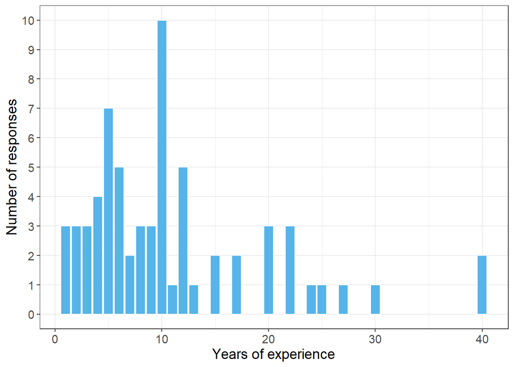

```r
figure_number <- 2

My_Theme <- theme(
    text = element_text(size = 14),
    axis.title.x = element_text(size = 14),
    axis.title.y = element_text(size = 14)
)

analysis_sample %>%
    ggplot(aes(x = years_experience)) +
    geom_bar(color = "white", fill = "#56B4E9") +
    theme_bw() +
    labs(y = "Number of responses",
         x = "Years of experience") +
    My_Theme +
    scale_y_continuous(breaks = seq(0, ceiling(max(analysis_sample$years_experience)), 1), minor_breaks = NULL)
```

```r
ggsave(filename = here::here("figures",
                     paste0("Fig", figure_number,
                         "_years_experience.png")),
     width = 8, height = 5, dpi = 500,
     type = "cairo")
figure_number <- figure_number + 1
```

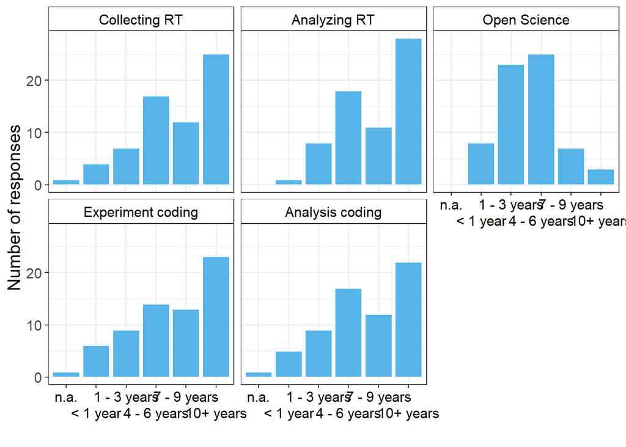

```r
df_years_experience <- analysis_sample %>%
    select(pseudo_ResponseID,
         starts_with("years_")) %>%
    select(-years_experience) %>%
    pivot_longer(-pseudo_ResponseID,
             names_to = "var_name",
             values_to = "var_value") %>%
    mutate(var_name = factor(var_name,
                     levels = c("years_CollectRT",
                             "years_AnalyseRT",
                             "years_OS",
                             "years_ExperimentCoding",
                             "years_AnalysisCoding"),
                     labels = c("Collecting RT",
                             "Analyzing RT",
                             "Open Science",
                             "Experiment coding",
                             "Analysis coding")))

df_years_experience <- df_years_experience %>%
    mutate(var_value = factor(var_value,
                      levels = c(NA,
                             "< 1 year",
                             "1 - 3 years",
                             "4 - 6 years",
                             "7 - 9 years",
                             "10+ years"),
                      labels = c("n.a.",
                             "< 1 year",
                             "1 - 3 years",
                             "4 - 6 years",
                             "7 - 9 years",
                             "10+ years"),
                      exclude = NULL))


df_years_experience %>%
    ggplot(aes(x = var_value)) +
    # fill with blue color, white borders of the bars
    geom_bar(color = "white", fill = "#56B4E9") +
    theme_bw() +
    facet_wrap(vars(var_name)) +
    scale_x_discrete(guide = guide_axis(n.dodge = 2)) +
    #text on the x axis is black
    theme(axis.text.x = element_text(colour = "black")) +
    # Change facet label  background colour
    theme(strip.background = element_rect(fill = "white")) +
    # Change facet label text colour
    theme(strip.text = element_text(colour = "black")) +
    labs(x = "",
         y = "Number of responses") +
    My_Theme
```

```r
ggsave(filename = here::here("figures",
                     paste0("Fig", figure_number,
                         "_years_involvement.png")),
     width = 10, height = 7, dpi = 500,
     type = "cairo")
figure_number <- figure_number + 1
```

# 3 Data exclusions

Frequency of excluding, reporting, and reporting the exact number of participants (part), stimuli, and trials due to:

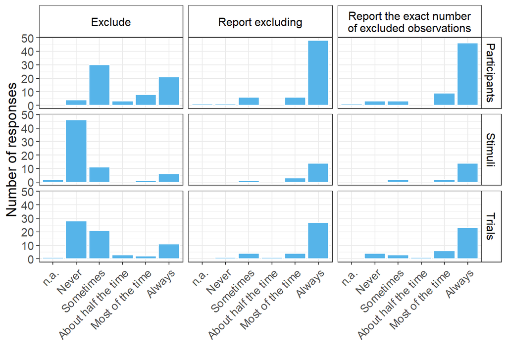

```r
aux_df <- analysis_sample %>%
    select(pseudo_ResponseID,
         contains("_ExtEvent_"),
         contains("_FixedCr_"),
         contains("_DataDepCr_")) %>%
    select(-contains("feedback"),
         -contains("importance"))
aux_df <- aux_df %>%
    pivot_longer(-pseudo_ResponseID,
             names_to = "var_name",
             values_to = "var_value")
aux_df <- aux_df %>%
    mutate(var_name = str_sub(var_name, start = 6)) %>%
    mutate(var_name = str_replace(var_name, "excl", "Exclude")) %>%
    mutate(var_name = str_replace(var_name, "rep_exact", "ReportExact")) %>%
    mutate(var_name = str_replace(var_name, "rep", "Report"))
aux_df <- aux_df %>%
    separate(var_name,
           into = c("excl_due_to", "do_what", "level_of_data"),
           sep = "_")
aux_df <- aux_df %>%
    mutate(var_value = factor(var_value,
                      levels = c(NA,
                             "Never",
                             "Sometimes",
                             "About half the time",
                             "Most of the time",
                             "Always"),
                      labels = c("n.a.",
                             "Never",
                             "Sometimes",
                             "About half the time",
                             "Most of the time",
                             "Always"),
                      exclude = NULL))

df_exclude <- aux_df %>%
    filter(do_what == "Exclude")

df_report <- df_exclude %>%
    filter(var_value %in% c("Sometimes",
                    "About half the time",
                    "Most of the time",
                    "Always")) %>%
    select(pseudo_ResponseID,
         excl_due_to,
         level_of_data) %>%
    left_join(aux_df %>%
                filter(do_what %in% c("Report", "ReportExact")),
            by = c("pseudo_ResponseID", "excl_due_to", "level_of_data"))

aux_df <- rbind(df_exclude,
            df_report)

aux_df <- aux_df %>%
    mutate(level_of_data = factor(level_of_data,
                        levels = c("part",
                                 "stimuli",
                                 "trials"),
                        labels = c("Participants",
                                 "Stimuli",
                                 "Trials"))) %>%
    mutate(do_what = factor(do_what,
                    levels = c("Exclude",
                             "Report",
                             "ReportExact"),
                    labels = c("Exclude",
                             "Report excluding",
                             "Report the exact number\nof excluded observations")))

aux_df %>%
    filter(excl_due_to %in% c("ExtEvent")) %>%
    ggplot(aes(x = var_value)) +
    # fill with blue color, white borders of the bars
    geom_bar(color = "white",fill = "#56B4E9") +
    theme_bw() +
    facet_grid(level_of_data ~ do_what) +
    theme(axis.text.x = element_text(angle = 45, hjust = 1)) +
    # Change facet label background colour
    theme(strip.background = element_rect(fill = "white")) +
    # Change facet label text colour
    theme(strip.text = element_text(colour = 'black')) +
    labs(y = "Number of responses",
         x = "") +
    My_Theme
```

```r
ggsave(filename = here::here("figures",
                     paste0("Fig", figure_number,
                         "_frequency_externalevents.png")),
     width = 10, height = 7, dpi = 500,
     type = "cairo")
figure_number <- figure_number + 1
```

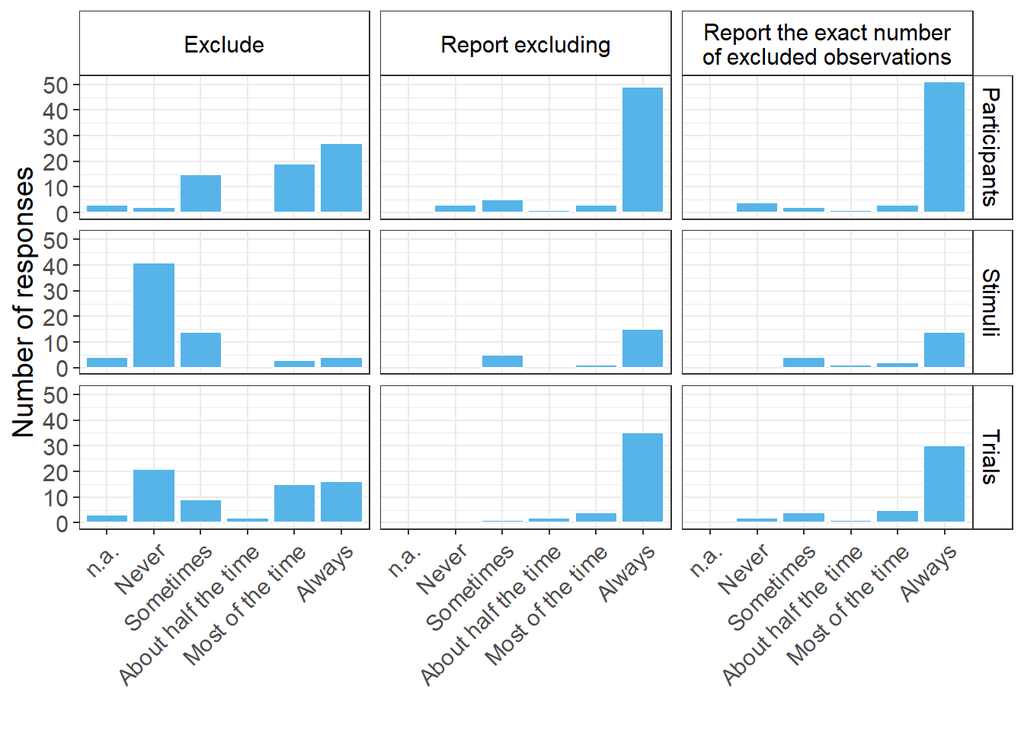

```r
aux_df %>%
    filter(excl_due_to %in% c("FixedCr")) %>%
    ggplot(aes(x = var_value)) +
    geom_bar(color = "white", fill = "#56B4E9") +
    theme_bw() +
    facet_grid(level_of_data ~ do_what) +
    theme(axis.text.x = element_text(angle = 45, hjust = 1)) +
    theme(strip.background = element_rect(fill = "white")) +
    theme(strip.text = element_text(colour = 'black')) +
    labs(y = "Number of responses",
         x = "") +
    My_Theme
```

```r
ggsave(filename = here::here("figures",
                     paste0("Fig", figure_number,
                         "_frequency_fixedcriteria.png")),
     width = 10, height = 7, dpi = 500,
     type = "cairo")
figure_number <- figure_number + 1
```

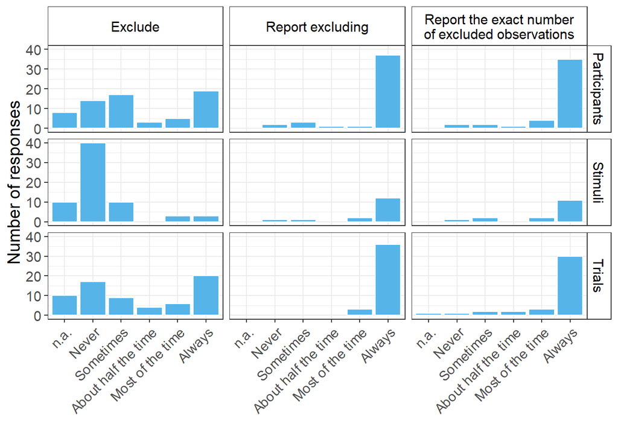

```r
aux_df %>%
    filter(excl_due_to %in% c("DataDepCr")) %>%
    ggplot(aes(x = var_value)) +
    geom_bar(color = "white", fill = "#56B4E9") +
    theme_bw() +
    facet_grid(level_of_data ~ do_what) +
    theme(axis.text.x = element_text(angle = 45, hjust = 1)) +
    theme(strip.background = element_rect(fill = "white")) +
    theme(strip.text = element_text(colour = 'black')) +
    labs(y = "Number of responses",
         x = "") +
    My_Theme
```

```r
ggsave(filename = here::here("figures",
                     paste0("Fig", figure_number,
                         "_frequency_datadependent.png")),
     width = 10, height = 7, dpi = 500,
     type = "cairo")
figure_number <- figure_number + 1

df_frequency <- aux_df
```

Importance (“How important do you think this processing step is for accuracy in analyses and interpretation?”)

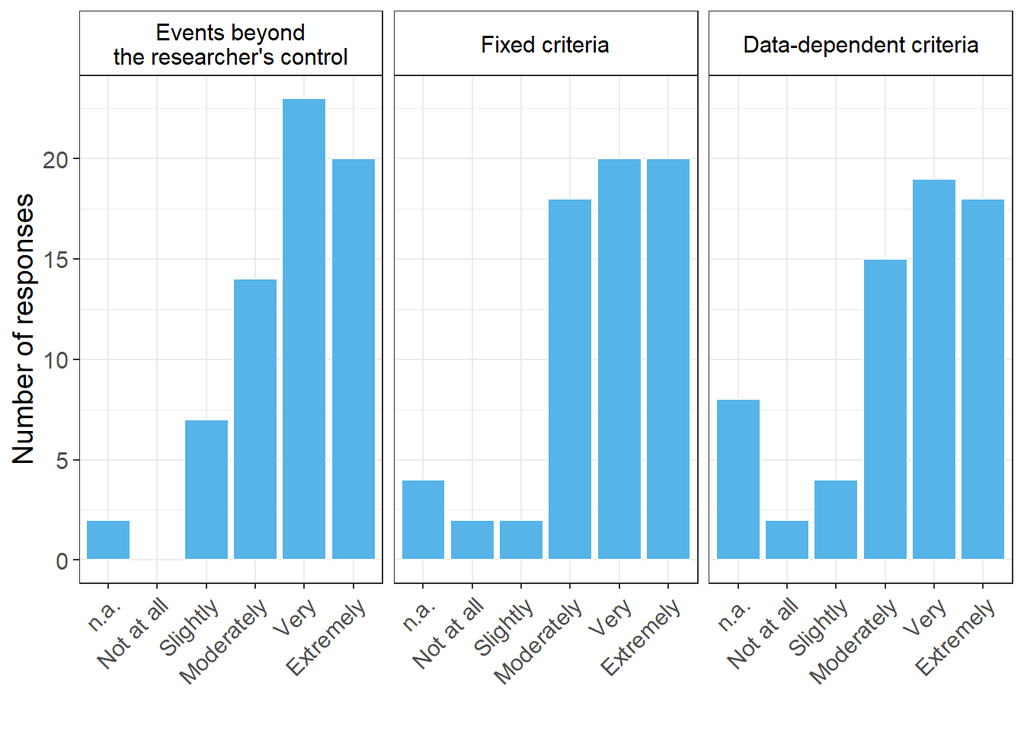

```r
aux_df <- analysis_sample %>%
    select(pseudo_ResponseID,
         contains("_ExtEvent_"),
         contains("_FixedCr_"),
         contains("_DataDepCr_")) %>%
    select(pseudo_ResponseID,
         contains("importance"))
aux_df <- aux_df %>%
    pivot_longer(-pseudo_ResponseID,
             names_to = "var_name",
             values_to = "var_value")
aux_df <- aux_df %>%
    mutate(var_name = str_remove(var_name, "excl_")) %>%
    mutate(var_name = str_remove(var_name, "_importance"))
aux_df <- aux_df %>%
    mutate(var_name = factor(var_name,
                     levels = c("ExtEvent",
                             "FixedCr",
                             "DataDepCr"),
                     labels = c("Events beyond\nthe researcher's control",
                             "Fixed criteria",
                             "Data-dependent criteria")))
aux_df <- aux_df %>%
    mutate(var_value = factor(var_value,
                      levels = c(NA,
                             "Not at all important",
                             "Slightly important",
                             "Moderately important",
                             "Very important",
                             "Extremely important"),
                      labels = c("n.a.",
                             "Not at all",
                             "Slightly",
                             "Moderately",
                             "Very",
                             "Extremely"),
                      exclude = NULL))

aux_df %>%
    ggplot(aes(x = var_value)) +
    geom_bar(color = "white", fill = "#56B4E9") +
    theme_bw() +
    facet_wrap(vars(var_name)) +
    theme(axis.text.x = element_text(angle = 45, hjust = 1)) +
    theme(strip.background = element_rect(fill = "white")) +
    theme(strip.text = element_text(colour = "black")) +
    labs(y = "Number of responses",
         x = "") +
    My_Theme
```

```r
ggsave(filename = here::here("figures",
                     paste0("Fig", figure_number,
                         "_importance_C123.png")),
     width = 10, height = 7, dpi = 500,
     type = "cairo")
figure_number <- figure_number + 1
```

# 4 Data processing and transformations

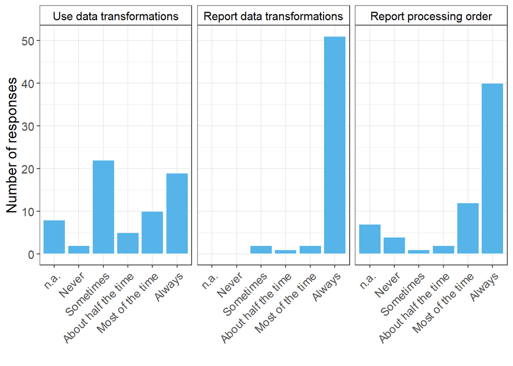

```r
aux_df <- analysis_sample %>%
    select(pseudo_ResponseID,
         contains("DataTrans"),
         contains("ProcOrder")) %>%
    select(-contains("importance"),
         -contains("feedback"))
aux_df <- aux_df %>%
    pivot_longer(-pseudo_ResponseID,
             names_to = "var_name",
             values_to = "var_value")
aux_df <- aux_df %>%
    mutate(var_name = str_remove(var_name, "freq_"))
aux_df <- aux_df %>%
    mutate(var_value = factor(var_value,
                      levels = c(NA,
                             "Never",
                             "Sometimes",
                             "About half the time",
                             "Most of the time",
                             "Always"),
                      labels = c("n.a.",
                             "Never",
                             "Sometimes",
                             "About half the time",
                             "Most of the time",
                             "Always"),
                      exclude = NULL))

df_use <- aux_df %>%
    filter(var_name == "DataTrans_do")

df_report <- df_use %>%
    filter(var_value %in% c("Sometimes",
                    "About half the time",
                    "Most of the time",
                    "Always")) %>%
    select(pseudo_ResponseID) %>%
    left_join(aux_df %>%
                filter(var_name == "DataTrans_report"),
            by = c("pseudo_ResponseID"))

aux_df <- rbind(df_use,
            df_report,
            aux_df %>%
                filter(var_name == "ProcOrder_report"))

aux_df <- aux_df %>%
    mutate(var_name = factor(var_name,
                     levels = c("DataTrans_do",
                             "DataTrans_report",
                             "ProcOrder_report"),
                     labels = c("Use data transformations",
                             "Report data transformations",
                             "Report processing order")))

aux_df %>%
    ggplot(aes(x = var_value)) +
    geom_bar(color = "white", fill = "#56B4E9") +
    theme_bw() +
    ylab("Number of responses") +
    xlab("") +
    facet_wrap(vars(var_name)) +
    theme(axis.text.x = element_text(angle = 45, hjust = 1)) +
    theme(strip.background = element_rect(fill = "white")) +
    theme(strip.text = element_text(colour = "black")) +
    labs(y = "Number of responses",
         x = "") +
    My_Theme
```

```r
ggsave(filename = here::here("figures",
                     paste0("Fig", figure_number,
                         "_data_transformations.png")),
     width = 10, height = 7, dpi = 500,
     type = "cairo")
figure_number <- figure_number + 1
```

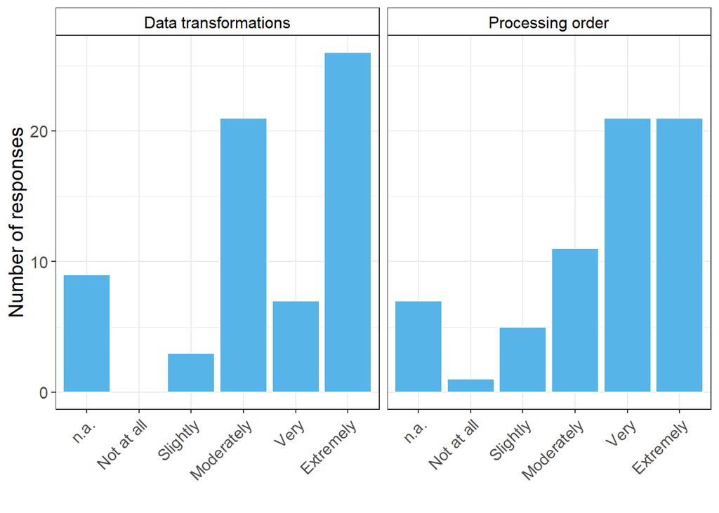

```r
aux_df <- analysis_sample %>%
    select(pseudo_ResponseID,
         contains("DataTrans"),
         contains("ProcOrder")) %>%
    select(pseudo_ResponseID,
         contains("importance"))
aux_df <- aux_df %>%
    pivot_longer(-pseudo_ResponseID,
             names_to = "var_name",
             values_to = "var_value")
aux_df <- aux_df %>%
    mutate(var_name = str_remove(var_name, "_importance"))
aux_df <- aux_df %>%
    mutate(var_name = factor(var_name,
                     levels = c("DataTrans",
                             "ProcOrder"),
                     labels = c("Data transformations",
                             "Processing order")))

aux_df <- aux_df %>%
    mutate(var_value = factor(var_value,
                      levels = c(NA,
                             "Not at all important",
                             "Slightly important",
                             "Moderately important",
                             "Very important",
                             "Extremely important"),
                      labels = c("n.a.",
                             "Not at all",
                             "Slightly",
                             "Moderately",
                             "Very",
                             "Extremely"),
                      exclude = NULL))

aux_df %>%
    ggplot(aes(x = var_value)) +
    geom_bar(color = "white", fill = "#56B4E9") +
    theme_bw() +
    facet_wrap(vars(var_name)) +
    theme(axis.text.x = element_text(angle = 45, hjust = 1)) +
    theme(strip.background = element_rect(fill = "white")) +
    theme(strip.text = element_text(colour = "black")) +
    labs(y = "Number of responses",
         x = "") +
    My_Theme
```

```r
ggsave(filename = here::here("figures",
                     paste0("Fig", figure_number,
                         "_importance_data_transformations.png")),
     width = 10, height = 7, dpi = 500,
     type = "cairo")
figure_number <- figure_number + 1
```

# 5 Likelihood of reproducibility

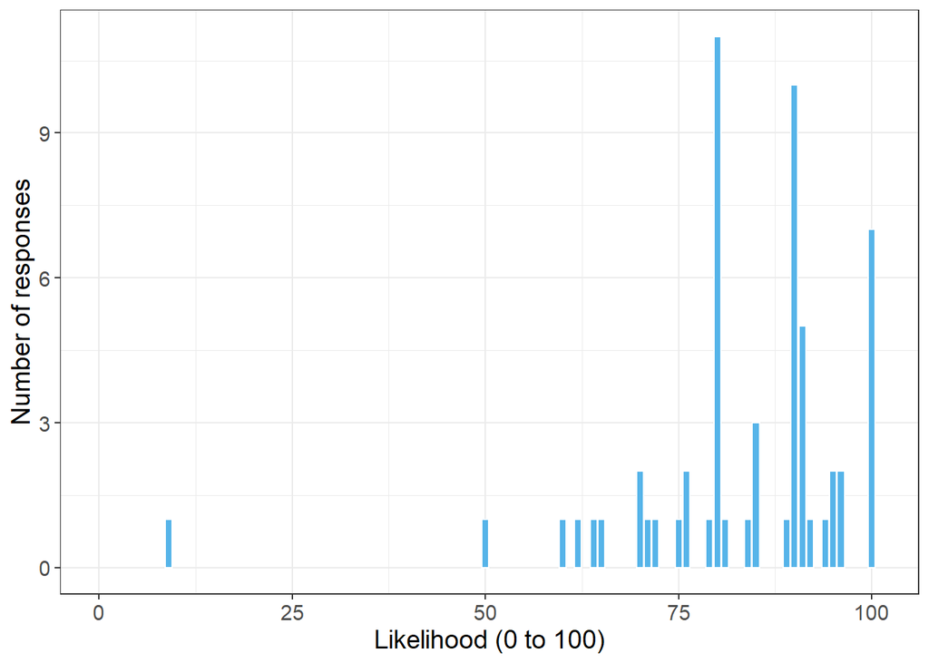

```r
analysis_sample %>%
    filter(!is.na(likelihood_reproduce)) %>%
    arrange(likelihood_reproduce) %>%
    ggplot(aes(x = likelihood_reproduce)) +
    geom_bar(color = "white", fill = "#56B4E9") +
    theme_bw() +
    theme(strip.background = element_rect(fill = "#56B4E9")) +
    theme(strip.text = element_text(colour = "black")) +
    labs(y = "Number of responses",
         x = "Likelihood (0 to 100)") +
    scale_x_continuous(limits = c(0, 101)) +
    My_Theme
```

```r
ggsave(filename = here::here("figures",
                     paste0("Fig", figure_number,
                         "_likelihood.png")),
     width = 7, height = 4, dpi = 500,
     type = "cairo")
figure_number <- figure_number + 1

mean(analysis_sample$likelihood_reproduce, na.rm = T)
```

```
## [1] 83.23729
```

```r
sd(analysis_sample$likelihood_reproduce, na.rm = T)
```

```
## [1] 14.86182
```

Checks against reports for how often observations are excluded.

Participants report how often they exclude observations for each of three exclusion criteria and three types of observations (i.e., participants, stimuli, trials). This corresponds to each participant providing nine responses to ‘How often do you exclude …?’. Participants who exclude observations at least sometimes for each of the nine combinations (exclusion criteria * type of observations) have a score of 9.

```r
aux_df <- df_frequency %>%
    filter(do_what == "Exclude")
aux_df <- aux_df %>%
    mutate(is_excluding = if_else(var_value %in% c("Sometimes",
                                     "About half the time",
                                     "Most of the time",
                                     "Always"),
                        1, 0))
aux_df <- aux_df %>%
    group_by(pseudo_ResponseID) %>%
    summarise(n_times_excluding = sum(is_excluding)) %>%
    ungroup()

aux_df %>%
    group_by(n_times_excluding) %>%
    summarise(n()) %>%
    ungroup()
```

```
## # A tibble: 9 × 2
##   n_times_excluding `n()`
##               <dbl> <int>
## 1                 1     4
## 2                 2     4
## 3                 3     6
## 4                 4    10
## 5                 5    14
## 6                 6    14
## 7                 7     4
## 8                 8     2
## 9                 9     8
```

All participants exclude observations for at least one of the nine situations. Eight participants report excluding observations for all of the nine criteria and types combinations. Next, I will calculate an average score of how often each participants reports the exact number of excluded observations (average over the nine situations).

```r
aux_test <- df_frequency %>%
    filter(do_what == "Report the exact number\nof excluded observations")
aux_test <- aux_test %>%
    mutate(num_value = as.integer(var_value) - 2)
aux_test %>%
    group_by(num_value,
           var_value) %>%
    summarise(n())
```

```
## # A tibble: 6 × 3
## # Groups:   num_value [6]
##   num_value var_value           `n()`
##       <dbl> <fct>               <int>
## 1        -1 n.a.                    2
## 2         0 Never                  17
## 3         1 Sometimes              24
## 4         2 About half the time     7
## 5         3 Most of the time       36
## 6         4 Always                254
```

```r
aux_test <- aux_test %>%
    mutate(num_value = if_else(num_value == -1, 0, num_value))
aux_test <- aux_test %>%
    group_by(pseudo_ResponseID) %>%
    summarise(num_value = mean(num_value)) %>%
    ungroup()
aux_test <- aux_test %>%
    left_join(analysis_sample %>%
                select(pseudo_ResponseID,
                     likelihood_reproduce),
            by = c("pseudo_ResponseID"))
```

The correlation between stated likelihood to reproduce and stated frequency of reporting the exact number of excluded observations is:

```r
cor.test(aux_test$num_value, aux_test$likelihood_reproduce)
```

```
##
##  Pearson's product-moment correlation
##
## data:  aux_test$num_value and aux_test$likelihood_reproduce
## t = 2.4798, df = 57, p-value = 0.01613
## alternative hypothesis: true correlation is not equal to 0
## 95 percent confidence interval:
##  0.06082996 0.52609303
## sample estimates:
##       cor
## 0.3120513
```

# 6 Software

```r
df_software <- analysis_sample %>%
    select(pseudo_ResponseID,
         software_collect,
         software_analyze)

# I will separate by comma, so I need to modify a few responses to make this easier
df_software <- df_software %>%
    pivot_longer(-pseudo_ResponseID,
             names_to = "software_used_for",
             values_to = "name_of_software")
df_software <- df_software %>%
    mutate(software_used_for = case_when(software_used_for == "software_collect" ~ "data_collection",
                             software_used_for == "software_analyze" ~ "data_analysis"))

df_software <- df_software %>%
    mutate(name_of_sw_edited = str_replace_all(name_of_software, pattern = "\\;", replacement = "\\,"))
df_software <- df_software %>%
    mutate(name_of_sw_edited = str_trim(name_of_sw_edited))

df_software <- df_software %>%
    mutate(name_of_sw_edited =
            case_when(name_of_sw_edited == "Depends. Often I get from gov't sources." ~ "not_specified",
                    name_of_sw_edited == "ePrime and Collector" ~ "eprime, collector",
                    name_of_sw_edited == "Gorilla Eprime others in the past we wrote the software ourselves" ~ "Gorilla, Eprime",
                    name_of_sw_edited == "jamovi, some recent work has been checked in both multi-level model and stimuli-as-fixed effects anova models in R by a highly trained person in MLM" ~ "jamovi, r",
                    name_of_sw_edited == "Mostly self developed software" ~ "not_specified",
                    name_of_sw_edited == "PsychoPy (offline, my own Python code), JavaScript (for online studies, again my own code, no frameworks)" ~ "PsychoPy, JavaScript",
                    name_of_sw_edited == "recently testable, sometimes proprietary web coding, previously a lot of superlab studies, a long time ago custom programmed stuff (not by me)" ~ "testable, not_specified, superlab, custom code",
                    name_of_sw_edited == "Spss R Jamovi Excel sometimes" ~ "Spss, R, Jamovi, Excel",
                    name_of_sw_edited == "used lots, but mostly R (on the q below, depends what you mean open science). Ignore the response since the q is poor." ~ "R, not_specified",
                    TRUE ~ name_of_sw_edited))
df_software <- df_software %>%
    mutate(name_of_sw_edited = str_to_lower(name_of_sw_edited))

df_software <- df_software %>%
    mutate(copy_sw = name_of_sw_edited) %>%
    separate(col = copy_sw,
           into = c("sw_1", "sw_2", "sw_3", "sw_4", "sw_5", "sw_6"),
           sep = "\\,",
           fill = "warn")
df_software <- df_software %>%
    pivot_longer(cols = starts_with("sw"),
             names_to = "var_name",
             values_to = "edited_software")

df_software <- df_software %>%
    filter(!is.na(edited_software))
df_software <- df_software %>%
    mutate(edited_software = str_trim(edited_software))
df_software <- df_software %>%
    filter(edited_software != "")

df_software <- df_software %>%
    mutate(edited_software = case_when(edited_software %in% c("custom code",
                                            "custom made online") ~ "custom",
                             edited_software == "e-prime" ~ "eprime",
                             edited_software == "jspsch" ~ "jspsych",
                             edited_software == "lab.js" ~ "labjs",
                             edited_software == "matlab ptb" ~ "matlab",
                             edited_software == "matlab/octave" ~ "matlab",
                             edited_software == "open sesame" ~ "opensesame",
                             edited_software == "psychpy" ~ "psychopy",
                             edited_software == "pyschopy" ~ "psychopy",
                             edited_software == "spss (at the beginning)" ~ "spss",
                             TRUE ~ edited_software))

df_software <- df_software %>%
    mutate(edited_software = if_else(str_detect(edited_software, "presentation"), "presentation", edited_software))

df_software %>%
    filter(software_used_for %in% c("data_collection")) %>%
    group_by(software_used_for, edited_software) %>%
    summarise(n_obs = n(),
            percent = n()/nrow(df_software)) %>%
    arrange(desc(n_obs)) %>%
    print(n = 100)
```

```
## # A tibble: 42 × 4
## # Groups:   software_used_for [1]
##    software_used_for edited_software                n_obs percent
##    <chr>             <chr>                          <int>   <dbl>
##  1 data_collection   eprime                            28 0.102
##  2 data_collection   psychopy                          28 0.102
##  3 data_collection   gorilla                            9 0.0328
##  4 data_collection   jspsych                            9 0.0328
##  5 data_collection   inquisit                           6 0.0219
##  6 data_collection   matlab                             6 0.0219
##  7 data_collection   presentation                       6 0.0219
##  8 data_collection   opensesame                         5 0.0182
##  9 data_collection   psychtoolbox                       5 0.0182
## 10 data_collection   labjs                              4 0.0146
## 11 data_collection   superlab                           4 0.0146
```

[output cut: 31 more lines]

```r
df_software %>%
    filter(software_used_for %in% c("data_analysis")) %>%
    group_by(software_used_for, edited_software) %>%
    summarise(n_obs = n(),
            percent = n()/nrow(df_software)) %>%
    arrange(desc(n_obs)) %>%
    print(n = 100)
```

```
## # A tibble: 16 × 4
## # Groups:   software_used_for [1]
##    software_used_for edited_software                               n_obs percent
##    <chr>             <chr>                                         <int>   <dbl>
##  1 data_analysis     r                                                60 0.219
##  2 data_analysis     spss                                             21 0.0766
##  3 data_analysis     jasp                                             12 0.0438
##  4 data_analysis     matlab                                            7 0.0255
##  5 data_analysis     python                                            7 0.0255
##  6 data_analysis     jamovi                                            6 0.0219
##  7 data_analysis     excel                                             3 0.0109
##  8 data_analysis     stan                                              2 0.00730
##  9 data_analysis     excel (for data preprocessing)                    1 0.00365
## 10 data_analysis     jags                                              1 0.00365
## 11 data_analysis     jamovi and earlier on spss                        1 0.00365
## 12 data_analysis     not_specified                                     1 0.00365
## 13 data_analysis     perl (for data preprocessing at the beginnin…     1 0.00365
## 14 data_analysis     sas                                               1 0.00365
## 15 data_analysis     statistica                                        1 0.00365
## 16 data_analysis     t                                                 1 0.00365
```

```r
aux_df <- df_software %>%
    filter(software_used_for == "data_analysis") %>%
    mutate(uses_R_for_analysis = if_else(edited_software == "r", 1, 0))

aux_df <- aux_df %>%
    group_by(pseudo_ResponseID) %>%
    summarise(uses_R_for_analysis = sum(uses_R_for_analysis)) %>%
    ungroup()

analysis_sample <- analysis_sample %>%
    left_join(aux_df,
            by = c("pseudo_ResponseID"))
```

# 7 Demographics

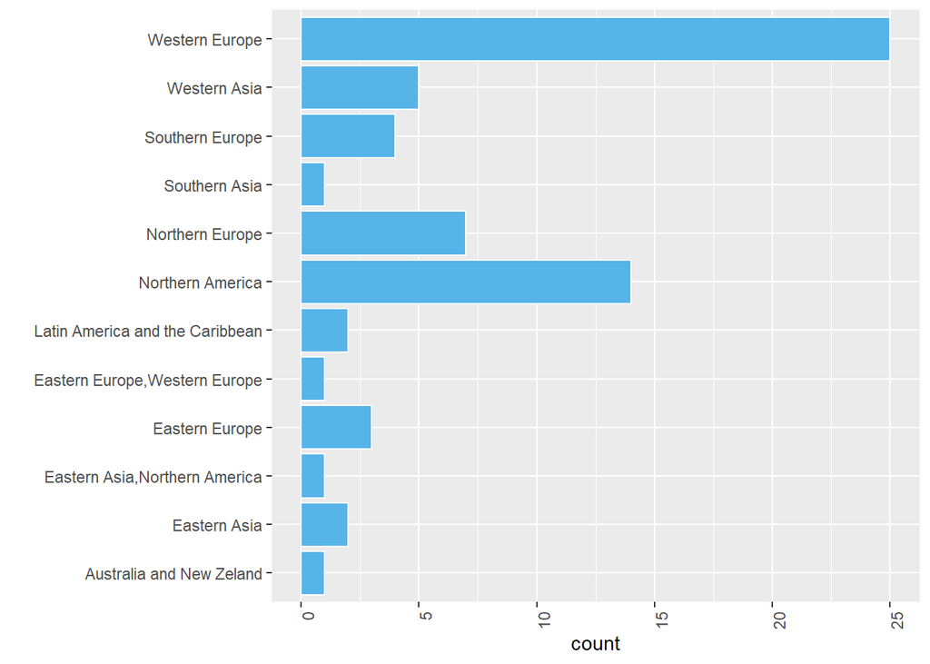

```r
analysis_sample %>%
    ggplot(aes(y = geographical_area)) +
    geom_bar(color = "white", fill = "#56B4E9") + #fill with blue color, white borders of the bars
    theme(axis.text.x = element_text(angle = 90, hjust = 1)) +
    ylab("")
```

```r
analysis_sample %>%
    group_by(geographical_area) %>%
    count() %>%
    arrange(n) %>%
    mutate(percent = n / nrow(analysis_sample))
```

```
## # A tibble: 12 × 3
## # Groups:   geographical_area [12]
##    geographical_area                   n percent
##    <chr>                           <int>   <dbl>
##  1 Australia and New Zeland            1  0.0152
##  2 Eastern Asia,Northern America       1  0.0152
##  3 Eastern Europe,Western Europe       1  0.0152
##  4 Southern Asia                       1  0.0152
##  5 Eastern Asia                        2  0.0303
##  6 Latin America and the Caribbean     2  0.0303
##  7 Eastern Europe                      3  0.0455
##  8 Southern Europe                     4  0.0606
##  9 Western Asia                        5  0.0758
## 10 Northern Europe                     7  0.106
## 11 Northern America                   14  0.212
## 12 Western Europe                     25  0.379
```

```r
analysis_sample <- analysis_sample %>%
    mutate(area_study = str_to_lower(area_study))
```

Number of times that specific terms were used to describe the area of study, by participants (n = 66) in the analysis sample:

- “cognitive”: n = 29
- “psychology”: n = 17
- “neuro”: n = 8
- “linguistics”: n = 11